# Real data examples

Mohamad Shakil Hasan

16 July 2017

#### Package version: OPWpaper 0.99.1

# Contents

Load the necessary libraries

```r
library(OPWpaper)
library(IHWpaper)
library(ggplot2)
library(reshape2)       # library for the melt function
library(cowplot)        # plot_grid function
library(dplyr)          # for %>%
```

# 1 Data examples

We performed simple regression with box-cox transformation to obtain the relationship between the test and the covariate in which covariate were regressed on the test statistics. Then, by applying the model’s information, we computed the predicted covariate for the median and the mean test statistics. The predicted covariate corresponding to the median and the mean were considered as the mean estimate of the covariate effect sizes. Note that, the diagnostic plots suggested that the models did not fit well. A pin-point model diagnosis process can improve the fitness of the model. This leaves a scope of further research, which is beyond our goal. However, the current model information is sufficient for our present purposes, because the proposed method only requires the centers of the test-effect sizes and the corresponding covariate-effect size.

## 1.1 Bottomly-RNA-seq data

1. Covariate is not normally distributed; therefore, we applied box-cox transformation in the simple linear regression.
2. Bimodal p-values indicates two-tailed test criteria are necessary because p-values close to $1$ be the cases that are significant in the opposite direction.
3. Low p-values are enriched at high covariates or low ranks of the covariate. This indicates that the covariate $basemean$ is correlated to the power under the alternative hypothesis test.
4. The empirical cumulative distribution shows whether the curve is almost linear for the high p-values.

Load the data stored in *OPWpaper*

```r
load(system.file("real_data_examples/results", "bottomly_data_example.RDATA",
                 package = "OPWpaper"), envir = environment())
```

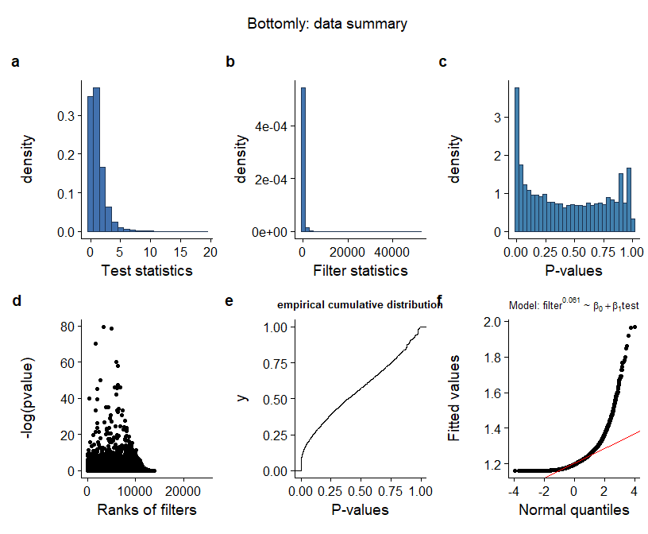

```r
# summary statistics of the data
#------------------------------------
p_bot = plot_grid(hist_test, hist_filter, hist_pval, pval_filter, p_ecdf, qqplot,
                   ncol = 3, labels = letters[1:6], align = 'hv')
title_bot <- ggdraw() + draw_label("Bottomly: data summary")
plot_grid(title_bot, p_bot, ncol = 1, rel_heights=c(.1, 1))
```

**Figure 1:** The summary information of the Bottomly-RNA-seq data. (a) Distribution of the test statistics, (b) Distribution of the covariate, (c) Distribution of the p-values, (d) negative $log(p-values)$ vs rank of the covariate (low index is for the better rank), (e) empirical cumulative distribution of the p-values, and (f) the $qqplot$ of the fitted values from the regression model with box-cox transformation.

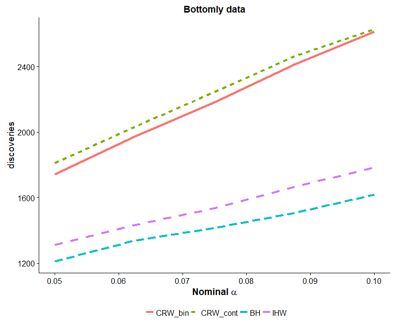

```r
# from IHW paper-------------
alpha = seq(.05, .1, length = 5)
bottomly_file <- system.file("real_data_examples/result_files", "RNAseq_benchmark.Rds", package = "IHWpaper")
rnaseq_data <- readRDS(file=bottomly_file)
panel_a_data <- group_by(rnaseq_data$alpha_df, alpha) %>% summarize(BH = max(bh_rejections), IHW=max(rejections))


# rejected test from different methods-------------
rej_mat_bot_FDR <- data.frame(n_rej_bin, n_rej_cont, panel_a_data)
colnames(rej_mat_bot_FDR) <- c("CRW_bin","CRW_cont", "alpha", "BH","IHW")
rej_mat_bot_FDR2 <- melt(rej_mat_bot_FDR, id.var = "alpha")

p_fdr_bot <- ggplot(rej_mat_bot_FDR2, aes(x = alpha, y = value, group = variable,
                                            colour = variable)) +
    geom_line(aes(linetype = variable), size = 1.5) +
    labs(x = expression(bold(paste("Nominal ",alpha))),
     y = "discoveries", title = "Bottomly data") +
    theme(legend.title = element_blank(), legend.position = "bottom")

p_fdr_bot
```

**Figure 2:** The number of rejected null hypotheses across different significance levels of $\alpha$. Here, CRW_bin = CRW binary, CRW_cont = CRW continuous, BH = Benjamini-Hochberg (Benjamini, Hochberg, and Kling 1997), and IHW = Independent Hypothesis Weighting methods (Ignatiadis et al. 2016).

## 1.2 Proteomics

1. Covariate is not normally distributed; therefore, we applied box-cox transformation in the simple linear regression.
2. Unimodal p-values indicates one-tailed test criteria are necessary.
3. There is a very weak relationship between high covariate values the rank of the covariate. This indicates that the covariate peptide counts is weakly correlated to the power under the alternative hypothesis test.

Load the data stored in *OPWpaper*

```r
load(system.file("real_data_examples/results", "proteomics_data_example.RDATA",
                 package = "OPWpaper"), envir = environment())
```

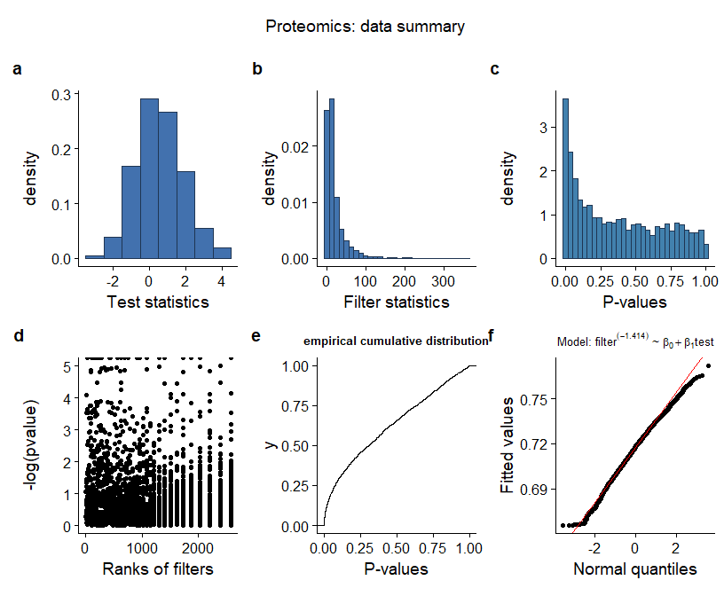

```r
# summary statistics of the data
#------------------------------------
p_prot = plot_grid(hist_test, hist_filter, hist_pval, pval_filter, p_ecdf, qqplot,
                  ncol = 3, labels = letters[1:6], align = 'hv')
title_prot <- ggdraw() + draw_label("Proteomics: data summary")
plot_grid(title_prot, p_prot, ncol = 1, rel_heights=c(.1, 1))
```

**Figure 3:** The summary information of the Proteomics data. (a) Distribution of the test statistics, (b) Distribution of the covariate, (c) Distribution of the p-values, (d) negative $log(p-values)$ vs rank of the covariate (low index is for the better rank), (e) empirical cumulative distribution of the p-values, and (f) the $qqplot$ of the fitted values from the regression model with box-cox transformation.

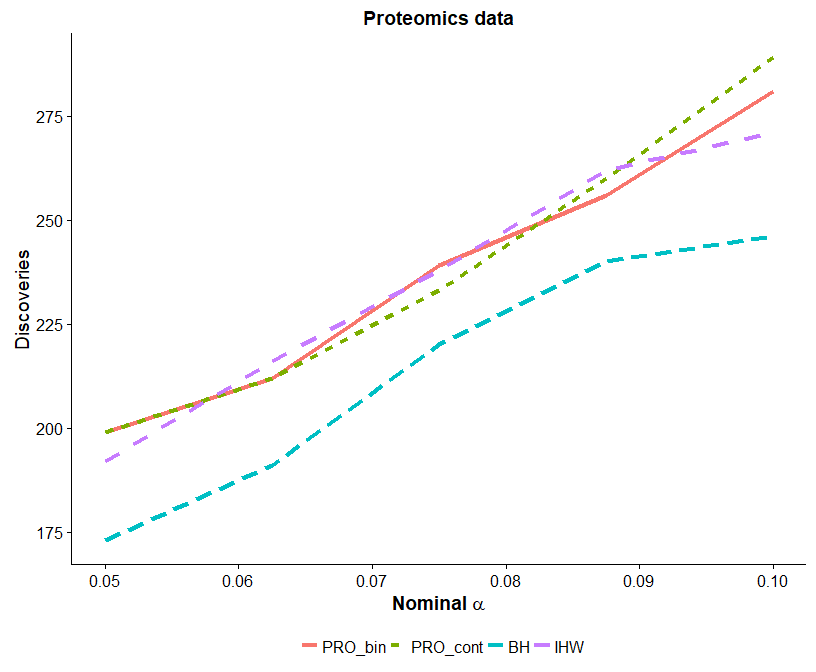

```r
# from IHW paper-------------
alpha = seq(.05, .1, length = 5)
proteomics_file <- system.file("real_data_examples/result_files", "proteomics_benchmark.Rds", package = "IHWpaper")
proteomics_data <- readRDS(file=proteomics_file)
panel_c_data <- group_by(proteomics_data$alpha_df, alpha) %>%
    summarize(BH = max(bh_rejections), IHW=max(rejections))


# rejected test from different methods-------------
rej_mat_prot_FDR <- data.frame(n_rej_bin, n_rej_cont, panel_c_data)
colnames(rej_mat_prot_FDR) <- c("PRO_bin","PRO_cont", "alpha", "BH","IHW")
rej_mat_prot_FDR2 <- melt(rej_mat_prot_FDR, id.var = "alpha")

p_fdr_prot <- ggplot(rej_mat_prot_FDR2, aes(x = alpha, y = value, group = variable,
                                            colour = variable)) +
    geom_line(aes(linetype = variable), size = 1.5) +
    labs(x = expression(bold(paste("Nominal ",alpha))),
       y = "Discoveries", title = "Proteomics data") +
    theme(legend.title = element_blank(), legend.position="bottom")

p_fdr_prot
```

**Figure 4:** The number of rejected null hypotheses across different significance levels of $\alpha$.

# References

Benjamini, Y, Y Hochberg, and Y Kling. 1997. “False Discovery Rate Control in Multiple Hypotheses Testing Using Dependent Test Statistics.” *Research Paper 97* 1.

Ignatiadis, Nikolaos, Bernd Klaus, Judith B Zaugg, and Wolfgang Huber. 2016. “Data-Driven Hypothesis Weighting Increases Detection Power in Genome-Scale Multiple Testing.” *Nature Methods*. doi:10.1038/nmeth.3885.